# Linear Algebra for Data Science

## Part 1A: Motivation & Real-World Connections

In this notebook, we will cover:

1. **Why Data Scientists need Linear Algebra**
2. **Real-world examples** (Linear Regression, Logistic Regression, PCA, Neural Networks)
3. **Quick overview of key Python tools** (NumPy, Pandas, etc.)

```python
# If running this in Google Colab or a fresh environment, uncomment the following:
# !pip install numpy pandas scikit-learn sympy matplotlib

import numpy as np
import pandas as pd
import matplotlib.pyplot as plt
from sklearn.linear_model import LinearRegression
```

## 1. Why Data Scientists Need Linear Algebra

**Linear Algebra** provides the mathematical foundation for many core algorithms in:

- **Machine Learning** (e.g., linear/logistic regression, SVMs, PCA)
- **Deep Learning** (neural networks rely on matrix multiplications for forward and backward propagation)
- **Data Transformations** (dimension reduction, feature engineering, etc.)

When working with data, you'll often represent:

- Datasets as *matrices* (rows = samples, columns = features).
- Transformations (rotations, scaling, projections) as *matrix operations*.
- Complex models (like neural networks) as repeated applications of linear and non-linear transformations.

Let's take a closer look at a few real-world examples where linear algebra is critical.

## 2. Real-World Examples

### 2.1 Linear Regression

Linear Regression tries to find a line (or hyperplane in higher dimensions) that best fits your data.  
It can be written in **matrix form** as:

$$ y = X\beta + \epsilon $$

where:

- $X$ is your **design matrix** of shape $(N \times p)$ (N = number of samples, p = number of features)
- $\beta$ is a **vector** of parameters (what we're solving for)
- $y$ is a vector of target values
- $\epsilon$ is the error (noise)

In matrix terms, finding the best-fit $\beta$ often involves:

$$\hat{\beta} = (X^T X)^{-1} X^T y $$

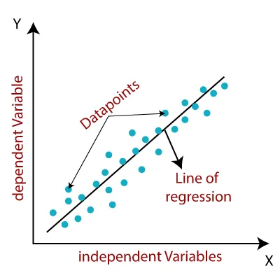

**Hands-on Demo**: We'll do a very quick linear regression demo with `scikit-learn` to illustrate.

```python
# Creating a small synthetic dataset
np.random.seed(42)  # For reproducibility
X = 2.5 * np.random.rand(100, 1)  # 100 samples, 1 feature
y = 4 + 3 * X.ravel() + np.random.randn(100) * 0.5  # true function: y = 4 + 3x + noise

# Converting to DataFrame for convenience (though not strictly necessary)
df = pd.DataFrame({'Feature': X.ravel(), 'Target': y})
df.head()
```

|  | Feature | Target |
| --- | --- | --- |
| 0 | 0.936350 | 6.852574 |
| 1 | 2.376786 | 10.980854 |
| 2 | 1.829985 | 9.535835 |
| 3 | 1.496646 | 7.496154 |
| 4 | 0.390047 | 5.060304 |

The first 5 rows of our tiny dataset:

```python
df.head()
```

|  | Feature | Target |
| --- | --- | --- |
| 0 | 0.936350 | 6.852574 |
| 1 | 2.376786 | 10.980854 |
| 2 | 1.829985 | 9.535835 |
| 3 | 1.496646 | 7.496154 |
| 4 | 0.390047 | 5.060304 |

Now, let's fit a linear regression model using `scikit-learn`:

```python
lin_reg = LinearRegression()
lin_reg.fit(X, y)

print("Intercept (b0):", lin_reg.intercept_)
print("Coefficient (b1):", lin_reg.coef_)
```

```
Intercept (b0): 4.107548078773375
Coefficient (b1): [2.90804535]
```

You should see numbers close to 4 and 3, respectively, because that's how we generated the data.

Let's visualize the fit:

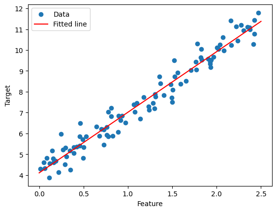

```python
plt.scatter(X, y, label='Data')
x_line = np.linspace(0, 2.5, 100).reshape(-1, 1)
y_pred = lin_reg.predict(x_line)
plt.plot(x_line, y_pred, color='red', label='Fitted line')
plt.xlabel('Feature')
plt.ylabel('Target')
plt.legend()
plt.show()
```

### Observations

- **Matrix form** behind the scenes: scikit-learn solves something akin to $\hat{\beta} = (X^TX)^{-1}X^Ty$ for a least-squares solution (with some optimizations).
- Linear Algebra is doing the heavy lifting.

### 2.2 Logistic Regression

- Logistic Regression also uses matrix operations, but it involves a non-linear *sigmoid* function.

(We'll skip a hands-on logistic regression demo for now—but be aware it’s also heavily dependent on linear algebra.)

[figure not shown]

- Gradient-based optimization (like **Gradient Descent**) relies on computing partial derivatives, which themselves rely on matrix/vector operations.

[figure not shown]

### 2.3 Principal Component Analysis (PCA)

- PCA is a **dimensionality reduction** technique.
- It uses the **eigen-decomposition** of the **covariance matrix** (or equivalently, **SVD** of the data matrix).
- By extracting the directions of maximum variance, PCA can reduce high-dimensional datasets to a few principal components.

In data science, we often apply PCA to visualize high-dimensional data or to reduce noise/features before modeling.

[figure not shown]

### 2.4 Neural Networks

- Deep neural networks (DNNs) typically perform many matrix multiplications:
  1. **Forward pass**: Multiply inputs by weight matrices, add biases, apply activation functions.
  2. **Backward pass**: Compute gradients via backpropagation (also heavily matrix-based).

For large-scale training (like images in convolutional neural networks), frameworks like **TensorFlow** or **PyTorch** optimize these matrix operations on GPUs/TPUs.

[figure not shown]

## 3. Quick Overview of Key Python Tools

When coding up these concepts, we'll primarily use:

1. **NumPy**: For array operations, linear algebra routines (`linalg.inv`, `linalg.eig`, etc.).
2. **Pandas**: For data manipulation, i.e., loading CSVs, handling missing data, slicing, etc.
3. **SciPy**: Additional linear algebra functionalities, optimization, etc.
4. **Sympy**: Useful to symbolically solve small systems or demonstrate math more transparently.
5. **Matplotlib** / **Seaborn**: For basic plots, data visualization, etc.

### Summary & Next Steps

In this notebook, we:

- Discussed how **Linear Algebra** underpins many Data Science tasks.
- Showed **real-world examples** (Regression, PCA, Neural Networks).
- Demonstrated a **quick overview of Python tools** (NumPy, Pandas, `matplotlib`) and did a small hands-on example in **Linear Regression**.

**Up Next**: We’ll start diving deeper into the **foundation of Linear Algebra**—Vectors, Matrices, and their operations.